# Communicate

Introduction to Quarto

Morgan Brucks, CCRP

University of Kansas Medical Center

July 29, 2026

## Learning Objectives

By the end of today’s session, you should be able to:

- understand how Quarto connects **text, code, and results**
- use Markdown, code chunks, and YAML to structure reproducible documents
- generate and customize figures, tables, citations, and outputs
- recognize how Quarto supports reproducible research communication

## Communicate

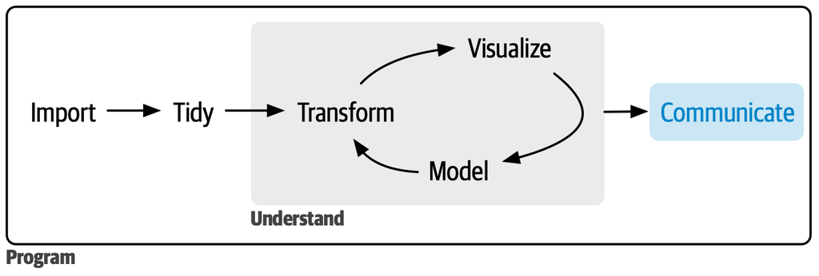

**R4DS Chapters 28-29**

| Chapter | Focus |
| --- | --- |
| 28 | Building reproducible Quarto documents |
| 29 | Creating different outputs and formats |

# Chapter 28: Quarto

## Basics

**What is Quarto?** A publishing system for creating reproducible documents by combining code, text, and visualizations.

**Every Quarto document contains four building blocks:**

- **YAML** – document settings (title, author, output)
- **Markdown** – narrative text
- **Code chunks** – R code that performs analyses
- **Rendered output** – tables, figures, and results

**Note**

Think of Quarto as a recipe:

- YAML decides what kind of meal you’re making (HTML report, PDF, presentation).
- Markdown provides the recipe and explanations.
- Code chunks prepare the ingredients and do the cooking (analysis).
- Rendering plates everything into the finished dish (your final document).

## Editors - Source

Quarto provides two ways to edit your documents: the Visual Editor for a word processor-like experience and the Source Editor for writing directly in Markdown. Both produce the same final document, so you can choose the workflow that best fits your needs.

**Source**

```markdown
## Text formatting

*italic* **bold** ~~strikeout~~ `code`

superscript^2^ subscript~2~

[underline]{.underline} [small caps]{.smallcaps}

## Headings

# 1st Level Header

## 2nd Level Header

### 3rd Level Header

## Lists

-   Bulleted list item 1

-   Item 2

    -   Item 2a

    -   Item 2b

1.  Numbered list item 1

2.  Item 2.
    The numbers are incremented automatically in the output.

## Links and images

<http://example.com>

[linked phrase](http://example.com)

![optional caption text](quarto.png){fig-alt="Quarto logo and the word quarto spelled in small case letters"}

## Tables

| First Header | Second Header |
|--------------|---------------|
| Content Cell | Content Cell  |
| Content Cell | Content Cell  |
```

## Editors - Visual

The visual editor is designed for users who prefer a graphical interface, making it easier to format documents, insert code, and create polished reports without needing to write all Markdown syntax manually.

**Visual**

[figure not shown]

## Markdown vs. HTML

Both Markdown and HTML can be used to format Quarto documents. **Markdown is the preferred syntax for most writing tasks because it is concise, readable, and easy to maintain.** HTML is available when you need additional formatting or customization.

| Feature | Markdown | HTML |
| --- | --- | --- |
| **Bold** | `**text**` | `<strong>text</strong>` |
| **Italic** | `*text*` | `<em>text</em>` |
| **Heading** | `## Heading` | `<h2>Heading</h2>` |
| **Bullet List** | `- Item` | `<ul><li>Item</li></ul>` |
| **Numbered List** | `1. Item` | `<ol><li>Item</li></ol>` |
| **Link** | `[Posit](https://posit.co)` | `<a href="https://posit.co">Posit</a>` |
| **Image** | `![Logo](logo.png)` | `<img src="logo.png">` |

**Example: Custom HTML Styling**

```html
<a href="https://posit.co"
   style="color:#0055A4; font-weight:bold; text-decoration:none;">
Visit Posit
</a>
```

Markdown cannot easily apply custom colors or styles, but HTML can.

**Hadley’s Philosophy**

**Use Markdown for almost everything.** It is easier to read, write, and collaborate on.

Use **HTML only when you need formatting that Markdown doesn’t support**, such as custom styling, colors, layouts, or embedded web content.

**Take-Home Message**

You do **not** need to learn HTML to be productive in Quarto. Markdown covers the vast majority of everyday writing tasks, while HTML is there when you need more control over the appearance of your document.

## Code Chunks

Code chunks execute your analysis and insert the results directly into your document. Chunk labels and options help organize your work while controlling what appears in the final output.

### Chunk Labels

Give chunks meaningful names so they are easier to identify, troubleshoot, and reference.

```
#| label: participant-demographics
```

### Chunk Options

Chunk options control **what your audience sees**, not what your code does.

| Option | Purpose |
| --- | --- |
| `echo: false` | Hide code, show output |
| `eval: false` | Show code, don’t run it |
| `warning: false` | Hide warnings |
| `message: false` | Hide package startup messages |

**Tip**

**Remember:**

- **`echo`** controls whether the **code is displayed**.
- **`eval`** controls whether the **code is executed**.

These options can be combined. For example, `echo: true` with `eval: false` displays the code without running it, while `echo: false` with `eval: true` runs the code but only displays the results.

### Global Options

Set default chunk behavior once using global execution options in the YAML header.

**Note**

**Chunk options** apply to a single chunk, while **global options** become the default for every chunk in your document.

## Figures and Tables

Quarto automatically creates publication-ready figures and tables directly from your analysis. Update your code, render the document, and every result stays synchronized.

**Display Code Only**

```r
library(ggplot2)

ggplot(mpg, aes(class)) +
  geom_bar()
```

`eval: false` displays the code without running it.

**Display Figure**

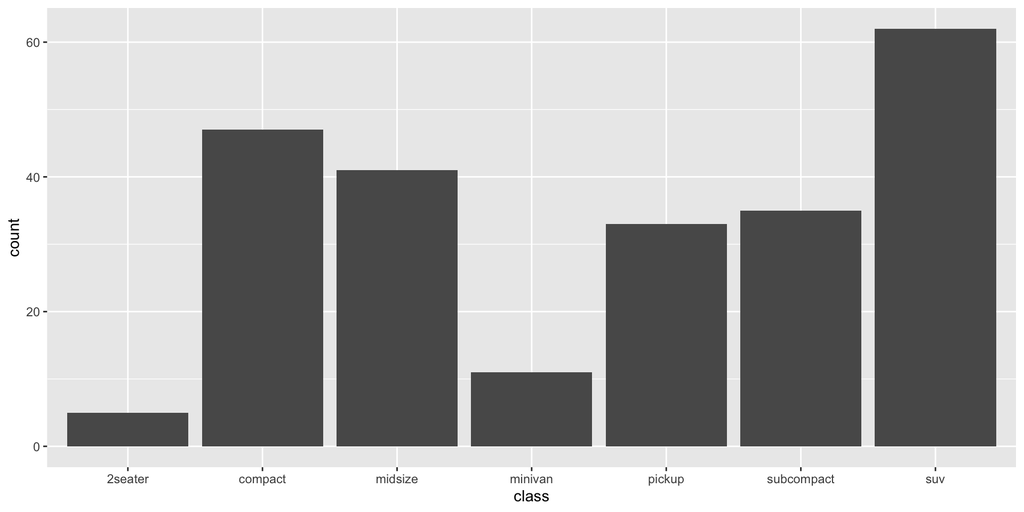

`echo: false` hides the code and displays only the figure.

**Tables in Quarto**

Quarto supports several table packages depending on your desired output. Here are two of the most commonly used.

`gt`

**Source**

```r
library(gt)

mtcars |>
  head() |>
  gt() |>
  fmt_number(
    columns = mpg,
    decimals = 1
  )
```

**Output**

| mpg | cyl | disp | hp | drat | wt | qsec | vs | am | gear | carb |
| --- | --- | --- | --- | --- | --- | --- | --- | --- | --- | --- |
| 21.0 | 6 | 160 | 110 | 3.90 | 2.620 | 16.46 | 0 | 1 | 4 | 4 |
| 21.0 | 6 | 160 | 110 | 3.90 | 2.875 | 17.02 | 0 | 1 | 4 | 4 |
| 22.8 | 4 | 108 | 93 | 3.85 | 2.320 | 18.61 | 1 | 1 | 4 | 1 |
| 21.4 | 6 | 258 | 110 | 3.08 | 3.215 | 19.44 | 1 | 0 | 3 | 1 |
| 18.7 | 8 | 360 | 175 | 3.15 | 3.440 | 17.02 | 0 | 0 | 3 | 2 |
| 18.1 | 6 | 225 | 105 | 2.76 | 3.460 | 20.22 | 1 | 0 | 3 | 1 |

`flextable`

**Source**

```r
library(flextable)

mtcars |>
  head() |>
  flextable() |>
  colformat_num(
    j = "mpg",
    digits = 1
  )
```

**Output**

| mpg | cyl | disp | hp | drat | wt | qsec | vs | am | gear | carb |
| --- | --- | --- | --- | --- | --- | --- | --- | --- | --- | --- |
| 21.0 | 6 | 160 | 110 | 3.90 | 2.620 | 16.46 | 0 | 1 | 4 | 4 |
| 21.0 | 6 | 160 | 110 | 3.90 | 2.875 | 17.02 | 0 | 1 | 4 | 4 |
| 22.8 | 4 | 108 | 93 | 3.85 | 2.320 | 18.61 | 1 | 1 | 4 | 1 |
| 21.4 | 6 | 258 | 110 | 3.08 | 3.215 | 19.44 | 1 | 0 | 3 | 1 |
| 18.7 | 8 | 360 | 175 | 3.15 | 3.440 | 17.02 | 0 | 0 | 3 | 2 |
| 18.1 | 6 | 225 | 105 | 2.76 | 3.460 | 20.22 | 1 | 0 | 3 | 1 |

**Note**

**Choosing a table package**

- **`gt`** creates polished, publication-quality tables and works especially well for HTML reports.
- **`flextable`** is designed for Microsoft Word and PowerPoint, making it a great choice for collaborators and manuscripts.

## YAML: Configuring Your Document

YAML is the header section of a Quarto document that provides instructions for how your document should be created and formatted.

Think of YAML as the **configuration file** for your document.

YAML can:

- define document information
- customize appearance
- add extensions and functionality
- control formatting behavior

Example:

```yaml
---
title: "Exercise Intervention Results"
author: "Morgan Brucks"
format: html
---
```

**Note**

YAML is processed before your R code runs. It tells Quarto how to build your final document.

## Extending and Styling Quarto

Quarto provides multiple ways to customize your documents beyond the default settings.

| Tool | Purpose | Example Uses |
| --- | --- | --- |
| **Quarto extensions** | Add reusable functionality | templates, themes, publishing workflows |
| **CSS** | Customize HTML appearance | colors, fonts, spacing, layouts |
| **SCSS** | Build advanced CSS styles | reusable style systems |
| **Lua filters** | Modify document behavior | custom formatting rules |
| **LaTeX** | Customize PDF output | manuscript formatting |

**Tip**

Most users will customize Quarto through YAML, themes, and CSS. Advanced tools like Lua filters and LaTeX provide additional control when needed.

## Example: Styling with YAML

YAML can connect your document to themes, stylesheets, and other custom resources.

```yaml
format:
  html:
    theme: cosmo
    css: styles.css
```

Quarto extensions allow you to customize fonts, colors, spacing, page layout, and document branding to create a consistent look and feel across projects. Explore the quarto-kansas repository for an example of a custom Quarto extension.

## Citations in Quarto

Quarto can automatically manage citations and references using a bibliography file.

The bibliography is connected through the YAML header:

```yaml
---
title: "Exercise Intervention Results"
author: "Morgan Brucks"
format: html
bibliography: references.bib
csl: https://www.zotero.org/styles/apa
---
```

**Adding Citations**

Citations are added directly within the text using the author-year citation key.

Example:

```markdown
Regular physical activity is associated with improved health outcomes
[@piercy2018].
```

Quarto automatically formats the citation:

> Regular physical activity is associated with improved health outcomes (Piercy et al., 2018).

**Reference List**

At the end of the document, Quarto automatically generates:

```markdown
## References
```

from the entries stored in:

```
references.bib
```

**Note**

References are stored separately from the document content, making citations reusable and automatically updated across projects.

For a complete example of manuscript writing and citation management in Quarto, explore the quarto-manuscript template.

## Troubleshooting Quarto

Most Quarto errors come from three places:

| Error Type | Common Errors | Check Here |
| --- | --- | --- |
| **R Code** | Package not installed, object not found, syntax errors | Code chunk |
| **Quarto / YAML** | Incorrect indentation, missing `:`, invalid YAML options | YAML header |
| **Markdown** | Unclosed code chunks, missing brackets, missing parentheses or quotation marks | Document text |

**Tip**

**Debugging workflow**

1. Read the error message
2. Find the line where the error occurred
3. Determine whether it’s an R, YAML, or Markdown error
4. Fix one issue at a time
5. Render again

## Chapter 28 Summary: Quarto

Quarto combines **text, code, and results** into reproducible documents.

**Key Concepts**

| Concept | Purpose |
| --- | --- |
| **Quarto documents** | Combine narrative, analysis, and outputs in one place |
| **Markdown** | Create readable, structured documents using simple syntax |
| **Code chunks** | Execute R code and insert results automatically |
| **Chunk options** | Control what code and output appear |
| **Figures & tables** | Generate reproducible, publication-ready outputs |
| **YAML** | Configure document settings and customization |
| **Citations** | Manage references automatically through bibliography files |

**Tip**

**The Quarto workflow**

Write → Analyze → Render → Communicate

When your data or code change, your document updates with them.

# Chapter 29: Quarto Formats

## Chapter 29: Quarto Formats

One Quarto document can be transformed into multiple output formats.

The content and analysis stay the same, while the final product changes based on the audience and purpose.

| Format | Best For | Example Uses |
| --- | --- | --- |
| **HTML** | Interactive web documents | Reports, dashboards, online supplements |
| **PDF** | Fixed-layout documents | Manuscripts, formal reports |
| **DOCX** | Editable documents | Collaborator drafts, reviews |
| **Revealjs** | HTML presentations | Research talks, workshops |
| **PPTX** | PowerPoint slides | Meetings, presentations |

## Interactivity with Shiny

Quarto can also create interactive applications using Shiny. Instead of a static report, interactive workflows allow user exploration.

[video not shown]

**Tip**

Shiny allows users to interact with results without needing to write R code.

## Chapter 29 Summary: Formats

Quarto allows researchers to communicate the same work in different ways.

**One Source → Many Outputs**

A single `.qmd` file can become:

- research reports
- manuscripts
- presentations
- interactive dashboards
- collaborator documents

**Note**

The goal is not creating more documents.

The goal is creating **one reproducible source that can be shared in many formats.**

## Best Practices for Quarto

A reproducible workflow requires more than code.

✓ Render often  
✓ Keep files organized  
✓ Write narrative alongside analysis  
✓ Document decisions  
✓ Use meaningful chunk labels  
✓ Save source files with projects  
✓ Embrace reproducibility

## Wrap-Up: Key Takeaways

**Chapter 28: Quarto**

Quarto brings together:

- **Narrative** → explain your work using Markdown
- **Code** → integrate analysis directly into documents
- **Results** → automatically generate figures and tables
- **Configuration** → customize documents through YAML
- **Citations** → manage references reproducibly

**Key idea:**

> A Quarto document connects the analysis process with the final communication product.

**Chapter 29: Quarto Formats**

Quarto allows one source document to become many outputs:

- reports
- manuscripts
- presentations
- Word documents
- interactive applications

**Key idea:**

> Write once. Render many ways.

**Tip**

Quarto is not just a document creation tool. It is a reproducible workflow for communicating research.

🎉 **Congratulations!**

You’ve learned the foundations of Quarto.

Now let’s put it all together and build your own presentation! 🚀

# Time to Practice!

## Build a Reproducible Quarto Workflow

Today you will combine the concepts from R4DS:

**Import → Transform → Program → Visualize → Communicate**

Your goal:

1. Create your own Quarto extension
2. Customize your document appearance
3. Import and transform data
4. Write reusable functions
5. Create a visualization

**Tip**

The goal is not just to make a plot.

The goal is to create a reproducible workflow that can be reused and shared.

## Activity 1: Create Your Own Quarto Extension

**Step 1:** Navigate to the code folder under your name in the 2026-RLAB-Practical-Exercises folder.

**Step 2:** Create an _extensions folder and a rlab folder inside extensions.

**Step 3:** Create an `_extensions.yml` and `custom.css` file inside the rlab folder.

**Step 4:** Add the following yaml to `_extensions.yml`:

```yaml
---
title: RLAB Quarto Format
author: Morgan Brucks
contributes:
  formats:
    html:
      title-block-banner: true
      theme: lumen
      css: custom.css
      embed-resources: true
      date-format: long
      code-copy: false
---
```

**Step 5:** Add the format and extension to the yaml of the `communication.qmd` file.

```yaml
---
format:
  rlab-html: default
---
```

**Step 6:** Copy the CSS from [this `custom.css` file](https://github.com/bhelsel/2026-RLAB-Practical-Exercises/tree/main/attendees/MorganBrucks/code/_extensions/rlab/custom.css) into the `custom.css` file that you just created.

**Step 7:** *Optional*. Experiment with ths css styling in `custom.css` by changing the images, colors, font sizes, etc. to make it your own.

## Activity 2: Data Science Review

**Import Data** In this exercise, you will create an in-memory DuckDB database, copy the nycflights13 datasets into it, and use dplyr to create a new data frame for analysis.

**Step 1:**

Create an in-memory DuckDB database by:

Connecting to DuckDB with DBI::dbConnect(). Using “:memory:” as the database location. Copying the nycflights13 datasets into the database with dbplyr::copy_nycflights13(). con <- DBI::dbConnect(duckdb::duckdb(), dbdir = “:memory:”)

dbplyr::copy_nycflights13(con)

**Step 2:**

Using the tables stored in DuckDB, create a new object named flights that:

- Starts with the weather table.
- Selects only the origin, time_hour, temp, and wind_speed columns.
- Joins the flights table using both origin and time_hour as the matching variables.
- Collects the resulting data into your R session using collect().

After completing these steps, the flights object should contain the selected weather variables along with the matching flight information, ready for use in later exercises.

## Activity 2 (ctd.): Data Science Review

**Write Your Own Filter Function**

Create a function named custom_filter() that filters a data frame based on a user-specified variable and value.

Your function should have three arguments:

- data: the data frame to filter.
- filter_by: the variable to use for filtering.
- value: the value to compare against.

Inside the function:

- Use dplyr::filter() to keep observations where the selected variable is greater than or equal to value.
- Use embracing ({{ }}) so that filter_by accepts an unquoted column name.

After writing your function, test it by creating a new object named filtered_flights that contains only rows where wind_speed is greater than or equal to 30 miles per hour.

If your function is written correctly, you should be able to call it by supplying a data frame, an unquoted variable name, and a comparison value.

## Activity 2 (ctd.): Data Science Review

**Write Your Own Visualization Function**

In this exercise, you will create a reusable function that produces a scatterplot using ggplot2. Your function should allow the user to choose the dataset, the variables to plot, and any optional arguments supported by ggplot2::geom_point().

**Step 1:**

Create a function named custom_visualization() with four arguments:

1. data: the data frame to plot.
2. xvar: the variable to display on the x-axis.
3. yvar: the variable to display on the y-axis.
4. … additional arguments that will be passed directly to ggplot2::geom_point().

**Step 2:**

- Use dplyr::filter().
- Inside filter(), use dplyr::if_any().
- Use embracing ({{ }}) so that the function accepts unquoted variable names.
- The condition should only keep rows that do not have an NA.

**Hint**: The expression inside if_any() should refer to the range from xvar to yvar, and the predicate should be is.na.

**Step 3:**

Pipe the filtered data into ggplot2::ggplot().

Use ggplot2::aes() to map:

- x to xvar
- y to yvar
- Remember to use embracing ({{ }}) for both variables.

**Step 4:**

Add a scatterplot layer using ggplot2::geom_point().

Instead of specifying arguments like color or size yourself, forward all optional arguments using …. This allows users to customize the points by passing any arguments accepted by geom_point(), such as: color, size, shape, fill, alpha, stroke, etc.

**Step 5:**

Test your function using the filtered_flights data frame. Create a scatterplot of:

- temp on the x-axis
- wind_speed on the y-axis

Customize the points by passing several optional arguments through …, for example:

color = “blue” size = 4 shape = 21 stroke = 2 fill = “red”

If your function is written correctly, these arguments should be passed automatically to ggplot2::geom_point() without modifying the function itself.